# Unit03 Ex2 linear_regression

Setup: fitted a simple linear regression using stats.linregress(x, y) and plotted the regression line over the scatter plot. Result: Pearson correlation r = -0.759, strong negative linear relationship. The fitted line slopes downward. Note: with a small dataset, the fitted line and correlation can be strongly influenced by single points. The negative correlation aligns with the negative slope, as x increases, the fitted line predicts lower y values.

```
Pearsons correlation: -0.759
```

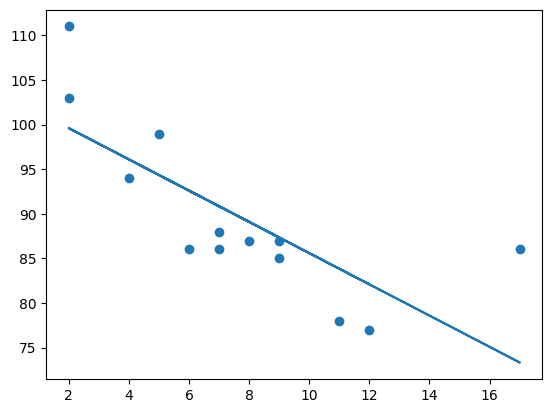

```python
import matplotlib.pyplot as plt
from scipy import stats

#Create the arrays that represent the values of the x and y axis
x = [5,7,8,7,2,17,2,9,4,11,12,9,6]
y = [99,86,87,88,111,86,103,87,94,78,77,85,86]

#Execute a method that returns some important key values of Linear Regression
slope, intercept, r, p, std_err = stats.linregress(x, y)

# measure the correlation
corr, _ = stats.pearsonr(x, y)
print('Pearsons correlation: %.3f' % corr)

#Create a function that uses the slope and intercept values to return a new value.
#This new value represents where on the y-axis the corresponding x value will be placed
def myfunc(x):
  return slope * x + intercept

#Run each value of the x array through the function. This will result in a new array with new values for the y-axis
mymodel = list(map(myfunc, x))

#Draw the original scatter plot & the line of linear regression
plt.scatter(x, y)
plt.plot(x, mymodel)
plt.show()
```

## Predict Future Values

```python
from scipy import stats

x = [5,7,8,7,2,17,2,9,4,11,12,9,6]
y = [99,86,87,88,111,86,103,87,94,78,77,85,86]

slope, intercept, r, p, std_err = stats.linregress(x, y)

def myfunc(x):
  return intercept + slope * x

speed = myfunc(10)

print(speed)
```

```
85.59308314937454
```

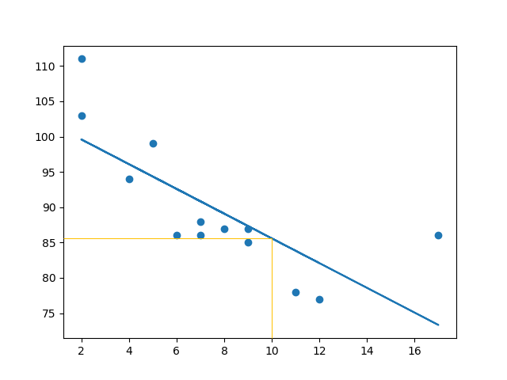

If x=10 then predicted y is 85.59

Setup: used ŷ = intercept + slope * x to predict y for a chosen x value. Result: for x = 10, predicted y ≈ 85.59. Note: this is a point prediction from a linear model, reliability depends on how well the linear trend represents the data. This prediction is interpolation because x = 10 lies within the observed x range.

```
Pearson correlation: 0.666
99.88581718038343
```

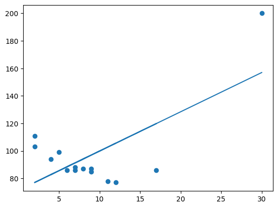

```python
import matplotlib.pyplot as plt
from scipy import stats

x = [5,7,8,7,2,17,2,9,4,11,12,9,6]
y = [99,86,87,88,111,86,103,87,94,78,77,85,86]

# outlier
x = x + [30]
y = y + [200]

slope, intercept, r, p, std_err = stats.linregress(x, y)

def myfunc(x):
    return intercept + slope * x

# predictions on the fitted line for each x
mymodel = list(map(myfunc, x))

corr, _ = stats.pearsonr(x, y)
print(f"Pearson correlation: {corr:.3f}")

# example single prediction
speed = myfunc(10)
print(speed)

# plot
plt.scatter(x, y)
plt.plot(x, mymodel)
plt.show()
```

Outlier sensitivity test Change: added one outlier point (30, 200) to the dataset. Result: Pearson correlation changed from -0.759 to 0.666 and the regression line reversed direction. Interpretation: Pearson correlation and least squares regression are highly sensitive to outliers, especially in small samples. One extreme observation can change both strength and direction of the inferred linear relationship.